# Tractometry Analysis

2023-04-07

# QA

## Summary

## Men

**Distribution of data**

The normality of the QA values was assessed using the shapiro-wilks test of normality. QA values from males was not normally distributed in the area **left cingulum** (p = 0.0221391) but normally distributed in the **right cingulum** (p=0.0896902), **Left fornix** (p=0.2152759), and **Right Fornix** (p = 0.2843453).

**Table 1.p values from normality tests using shapiro-wilks.**

|  | Left cingulum | Right cingulum | Left Fornix | Right Fornix |
| --- | --- | --- | --- | --- |
| Males | 0.0221391 | 0.0896902 | 0.2152759 | 0.2843453 |

**Descriptive stats**

```r
m_QA_cing_L_summary <- summary(m_QA$qa_Cingulum_L)
m_QA_cing_R_summary <- summary(m_QA$qa_Cingulum_R)

m_QA_fornix_R_summary <- summary(m_QA$qa_Fornix_R)
m_QA_fornix_L_summary <- summary(m_QA$qa_Fornix_L)

QA_male_summary <- rbind(m_QA_cing_L_summary, m_QA_cing_R_summary,m_QA_fornix_L_summary,m_QA_fornix_R_summary) %>% `row.names<-`(c("Left cingulum", "Right cingulum", "Left Fornix", "Right Fornix")) %>% as.data.frame()
```

|  | Min. | 1st Qu. | Median | Mean | 3rd Qu. | Max. |
| --- | --- | --- | --- | --- | --- | --- |
| Left cingulum | 0.196242 | 0.2060820 | 0.2125300 | 0.2207730 | 0.2314673 | 0.275876 |
| Right cingulum | 0.209888 | 0.2294798 | 0.2329750 | 0.2404063 | 0.2507523 | 0.294771 |
| Left Fornix | 0.177021 | 0.2049945 | 0.2225050 | 0.2206932 | 0.2293593 | 0.290630 |
| Right Fornix | 0.185399 | 0.2120980 | 0.2293515 | 0.2294108 | 0.2369195 | 0.300249 |

## Women

**Distribution of data**

The normality of the QA values was assessed using the shapiro-wilks test of normality. QA values from females was normally distributed in the **left cingulum** (p = 0.8220697) and **right cingulum** (p=0.4513893), **Left Fornix** (p= 0.1704547), **Right Fornix** (p= 0.2414461)

**Table 1. P values from normality tests using shapiro-wilks.**

|  | Left cingulum | Right cingulum | Left Fornix | Right Fornix |
| --- | --- | --- | --- | --- |
| Females | 0.8220697 | 0.4513893 | 0.1704547 | 0.2414461 |

**Descriptive stats**

|  | Min. | 1st Qu. | Median | Mean | 3rd Qu. | Max. |
| --- | --- | --- | --- | --- | --- | --- |
| Left cingulum | 0.176102 | 0.2160230 | 0.2314275 | 0.2310503 | 0.2465400 | 0.273095 |
| Right cingulum | 0.205419 | 0.2372515 | 0.2517830 | 0.2527070 | 0.2640577 | 0.299064 |
| Left Fornix | 0.204638 | 0.2241112 | 0.2414890 | 0.2422293 | 0.2545415 | 0.298557 |
| Right Fornix | 0.207777 | 0.2340737 | 0.2520255 | 0.2521456 | 0.2646310 | 0.307960 |

## T Tests

**P values from t tests**

| Left cingulum | Right cingulum | Left Fornix | Right Fornix |
| --- | --- | --- | --- |
| 0.0234633 | 0.0121928 | 7.5e-06 | 0.0003516 |

**Figures**

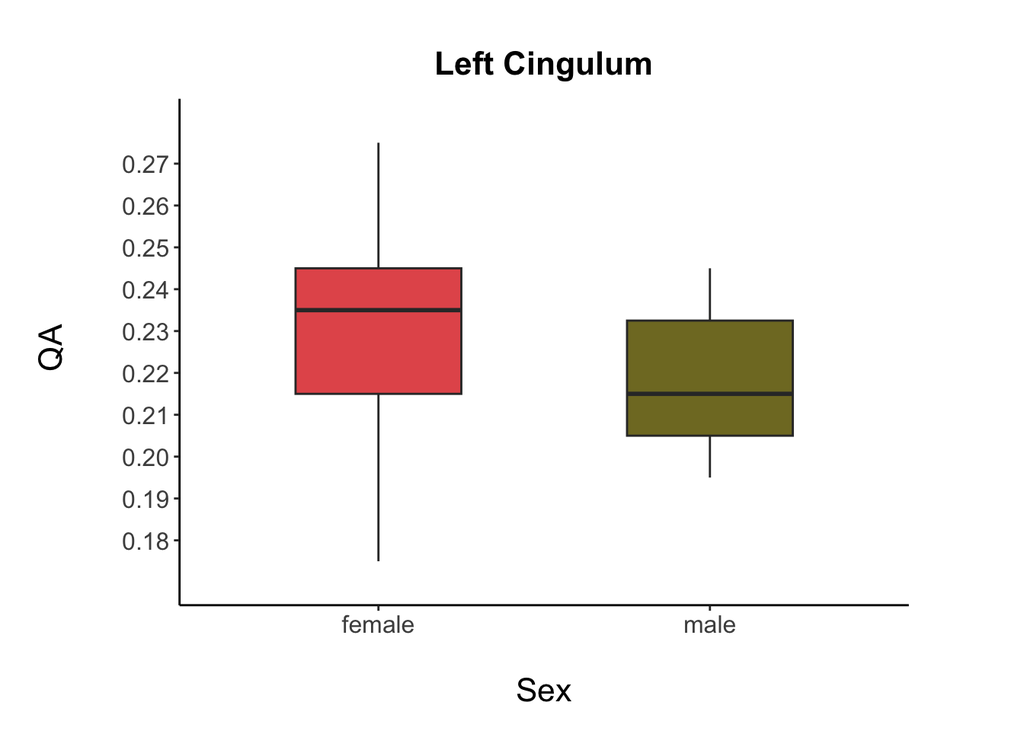

```r
  QA_L_Cing <- QAdf %>%
    ggplot(aes(x=sex, y= qa_Cingulum_L, group=sex)) +
      geom_boxplot(width=0.5 ,fill= c("#E45A5A", "#80792B")) +
      scale_y_binned(n.breaks=10, nice.breaks = TRUE) +
      labs(x= "Sex", y= " QA", title ="Left Cingulum" ) +
      theme(axis.title.x = element_text(vjust=- 4, size = 16),
            axis.title.y = element_text(vjust=8, size = 16),
            axis.text.x = element_text(size = 12),
            axis.text.y = element_text(size = 12),
            panel.background =element_blank(),
            axis.line = element_line(colour = "black"),
            plot.margin = margin(1, 2, 1, 1.5, "cm"),
            plot.title = element_text(hjust = 0.5, vjust = 2, size = 16, face="bold"))

print(QA_L_Cing)
```

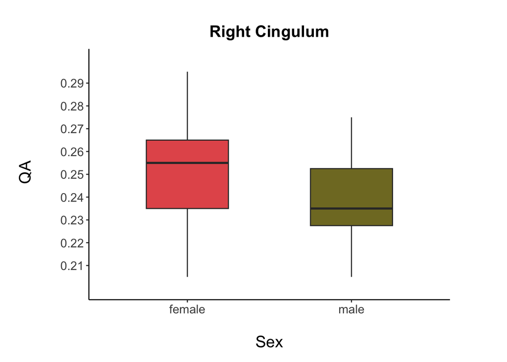

```r
QA_R_Cing <- QAdf %>%
    ggplot(aes(x=sex, y= qa_Cingulum_R, group=sex)) +
      geom_boxplot(width=0.5 ,fill= c("#E45A5A", "#80792B")) +
      scale_y_binned(n.breaks=10, nice.breaks = TRUE) +
      labs(x= "Sex", y= " QA", title ="Right Cingulum" ) +
      theme(axis.title.x = element_text(vjust=- 4, size = 16),
            axis.title.y = element_text(vjust=8, size = 16),
            axis.text.x = element_text(size = 12),
            axis.text.y = element_text(size = 12),
            panel.background =element_blank(),
            axis.line = element_line(colour = "black"),
            plot.margin = margin(1, 2, 1, 1.5, "cm"),
            plot.title = element_text(hjust = 0.5, vjust = 2, size = 16, face="bold"))

print(QA_R_Cing)
```

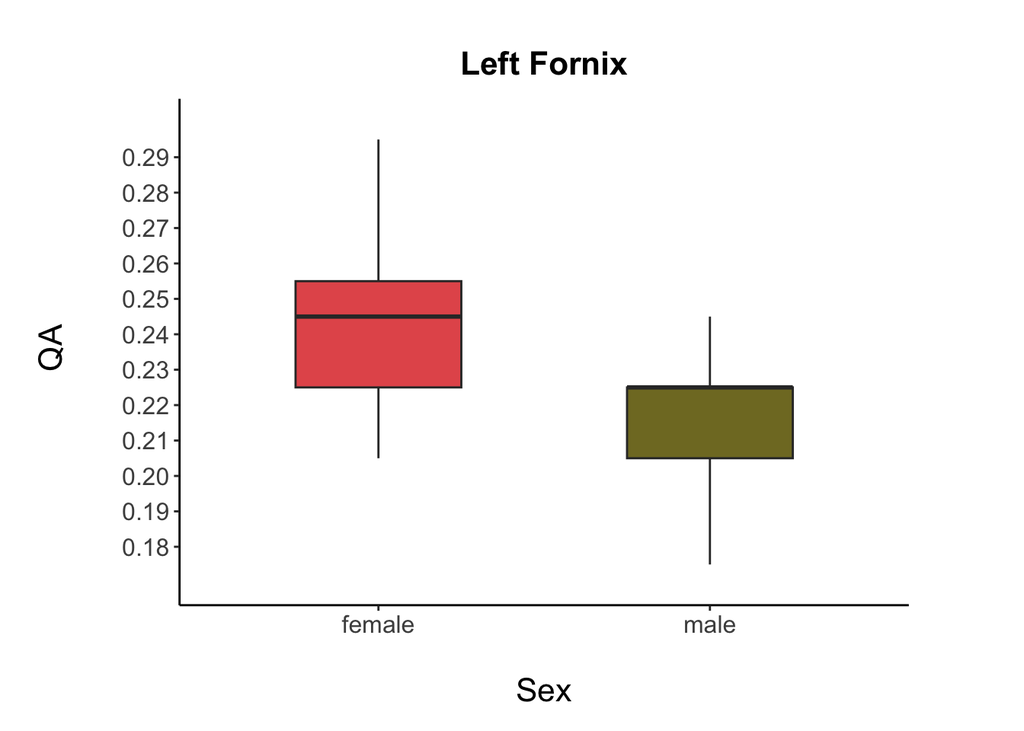

```r
QA_L_fornix <- QAdf %>%
    ggplot(aes(x=sex, y= qa_Fornix_L, group=sex)) +
      geom_boxplot(width=0.5 ,fill= c("#E45A5A", "#80792B")) +
      scale_y_binned(n.breaks=10, nice.breaks = TRUE) +
      labs(x= "Sex", y= " QA", title ="Left Fornix" ) +
      theme(axis.title.x = element_text(vjust=- 4, size = 16),
            axis.title.y = element_text(vjust=8, size = 16),
            axis.text.x = element_text(size = 12),
            axis.text.y = element_text(size = 12),
            panel.background =element_blank(),
            axis.line = element_line(colour = "black"),
            plot.margin = margin(1, 2, 1, 1.5, "cm"),
            plot.title = element_text(hjust = 0.5, vjust = 2, size = 16, face="bold"))

print(QA_L_fornix)
```

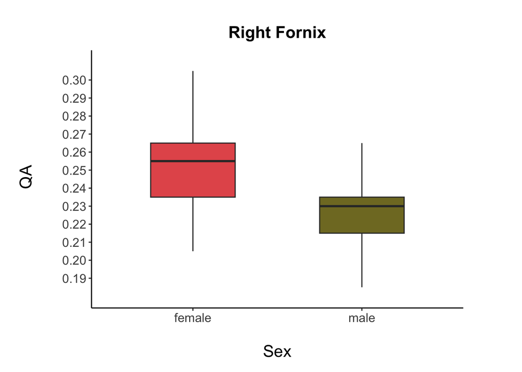

**Figure 4. QA Values for Right Fornix**

```r
QA_R_fornix <- QAdf %>%
    ggplot(aes(x=sex, y= qa_Fornix_R, group=sex)) +
      geom_boxplot(width=0.5 ,fill= c("#E45A5A", "#80792B")) +
      scale_y_binned(n.breaks=10, nice.breaks = TRUE) +
      labs(x= "Sex", y= " QA", title ="Right Fornix" ) +
      theme(axis.title.x = element_text(vjust=- 4, size = 16),
            axis.title.y = element_text(vjust=8, size = 16),
            axis.text.x = element_text(size = 12),
            axis.text.y = element_text(size = 12),
            panel.background =element_blank(),
            axis.line = element_line(colour = "black"),
            plot.margin = margin(1, 2, 1, 1.5, "cm"),
            plot.title = element_text(hjust = 0.5, vjust = 2, size = 16, face="bold"))

print(QA_R_fornix)
```

# MD

## Summary

## Men

**Distribution of data**

**Table 1.p values from normality tests using shapiro-wilks.**

|  | Left cingulum | Right cingulum | Left Fornix | Right Fornix |
| --- | --- | --- | --- | --- |
| Males | 0.9069731 | 0.5367833 | 0.0486174 | 0.2862947 |

**Descriptive stats**

```r
m_MD_cing_L_summary <- summary(m_MD$md_Cingulum_L)
m_MD_cing_R_summary <- summary(m_MD$md_Cingulum_R)

m_MD_fornix_R_summary <- summary(m_MD$md_Fornix_R)
m_MD_fornix_L_summary <- summary(m_MD$md_Fornix_L)

MD_male_summary <- rbind(m_MD_cing_L_summary, m_MD_cing_R_summary,m_MD_fornix_L_summary,m_MD_fornix_R_summary) %>% `row.names<-`(c("Left cingulum", "Right cingulum", "Left Fornix", "Right Fornix")) %>% as.data.frame()
```

|  | Min. | 1st Qu. | Median | Mean | 3rd Qu. | Max. |
| --- | --- | --- | --- | --- | --- | --- |
| Left cingulum | 0.727267 | 0.7727693 | 0.7859035 | 0.7840934 | 0.8017800 | 0.845455 |
| Right cingulum | 0.735939 | 0.7872765 | 0.7998685 | 0.7986994 | 0.8143502 | 0.847680 |
| Left Fornix | 0.935878 | 1.0063900 | 1.0213800 | 1.0501730 | 1.1000500 | 1.251080 |
| Right Fornix | 0.946590 | 1.0189100 | 1.0448350 | 1.0590537 | 1.1214900 | 1.236770 |

## Women

**Distribution of data**

The normality of the MD values was assessed using the shapiro-wilks test of normality. MD values from females was normally distributed in the **left cingulum** (p = 0.7054614) and **right cingulum** (p=0.8553172), **Left Fornix** (p= 0.0780938), **Right Fornix** (p= 0.2220468)

**Table 1.p values from normality tests using shapiro-wilks.**

|  | Left cingulum | Right cingulum | Left Fornix | Right Fornix |
| --- | --- | --- | --- | --- |
| Females | 0.7054614 | 0.8553172 | 0.0780938 | 0.2220468 |

**Descriptive stats**

```r
f_MD_cing_L_summary <- summary(f_MD$md_Cingulum_L)
f_MD_cing_R_summary <- summary(f_MD$md_Cingulum_R)

f_MD_fornix_R_summary <- summary(f_MD$md_Fornix_R)
f_MD_fornix_L_summary <- summary(f_MD$md_Fornix_L)

MD_female_summary <-
  rbind(
    f_MD_cing_L_summary,
    f_MD_cing_R_summary,
    f_MD_fornix_R_summary,
    f_MD_fornix_L_summary
  ) %>% `row.names<-`(c("Left cingulum", "Right cingulum", "Left Fornix", "Right Fornix")) %>% as.data.frame()
```

[output not shown]

## T Test

**P values from t tests**

| Left cingulum | Right cingulum | Left Fornix | Right Fornix |
| --- | --- | --- | --- |
| 0.1329231 | 0.0748811 | 0.735195 | 0.4179586 |

**Figures**

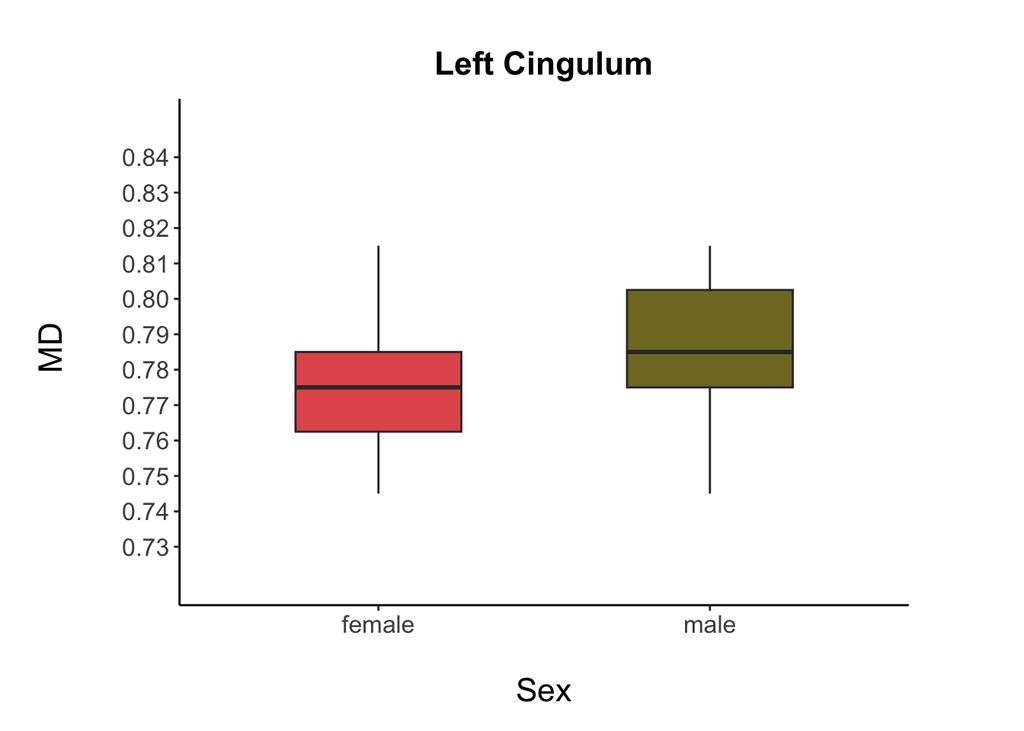

```r
  MD_L_Cing <- MDdf %>%
    ggplot(aes(x=sex, y= md_Cingulum_L, group=sex)) +
      geom_boxplot(width=0.5 ,fill= c("#E45A5A", "#80792B")) +
      scale_y_binned(n.breaks=10, nice.breaks = TRUE) +
      labs(x= "Sex", y= " MD", title ="Left Cingulum" ) +
      theme(axis.title.x = element_text(vjust=- 4, size = 16),
            axis.title.y = element_text(vjust=8, size = 16),
            axis.text.x = element_text(size = 12),
            axis.text.y = element_text(size = 12),
            panel.background =element_blank(),
            axis.line = element_line(colour = "black"),
            plot.margin = margin(1, 2, 1, 1.5, "cm"),
            plot.title = element_text(hjust = 0.5, vjust = 2, size = 16, face="bold"))

print(MD_L_Cing)
```

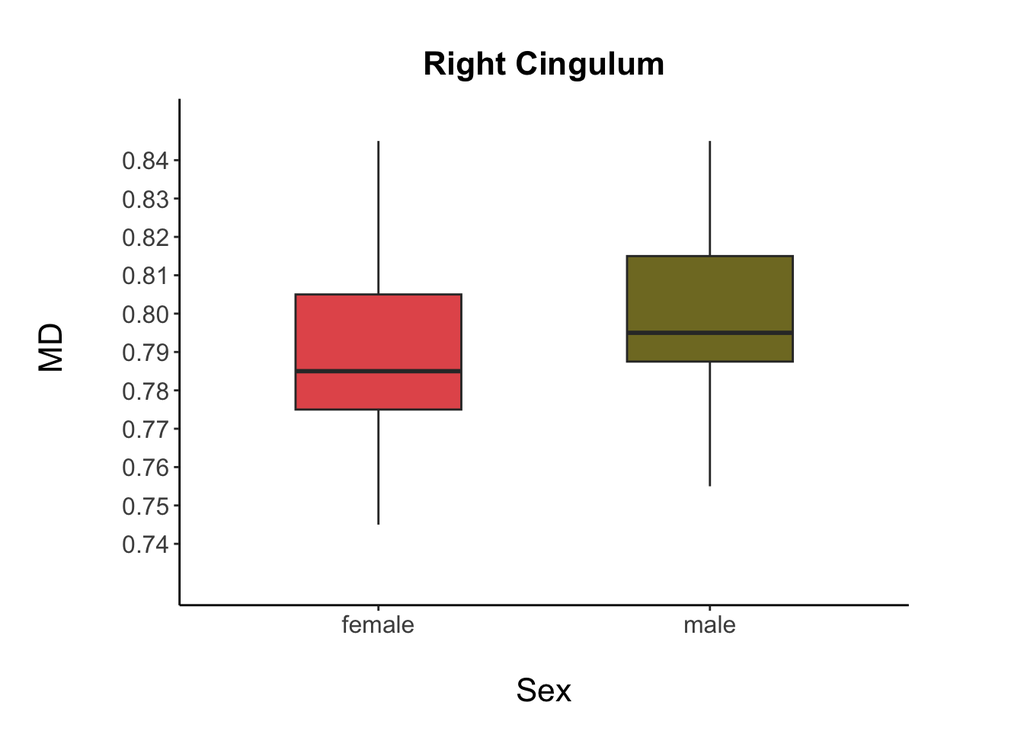

```r
  MD_R_Cing <- MDdf %>%
    ggplot(aes(x=sex, y= md_Cingulum_R, group=sex)) +
      geom_boxplot(width=0.5 ,fill= c("#E45A5A", "#80792B")) +
      scale_y_binned(n.breaks=10, nice.breaks = TRUE) +
      labs(x= "Sex", y= " MD", title ="Right Cingulum" ) +
      theme(axis.title.x = element_text(vjust=- 4, size = 16),
            axis.title.y = element_text(vjust=8, size = 16),
            axis.text.x = element_text(size = 12),
            axis.text.y = element_text(size = 12),
            panel.background =element_blank(),
            axis.line = element_line(colour = "black"),
            plot.margin = margin(1, 2, 1, 1.5, "cm"),
            plot.title = element_text(hjust = 0.5, vjust = 2, size = 16, face="bold"))

print(MD_R_Cing)
```

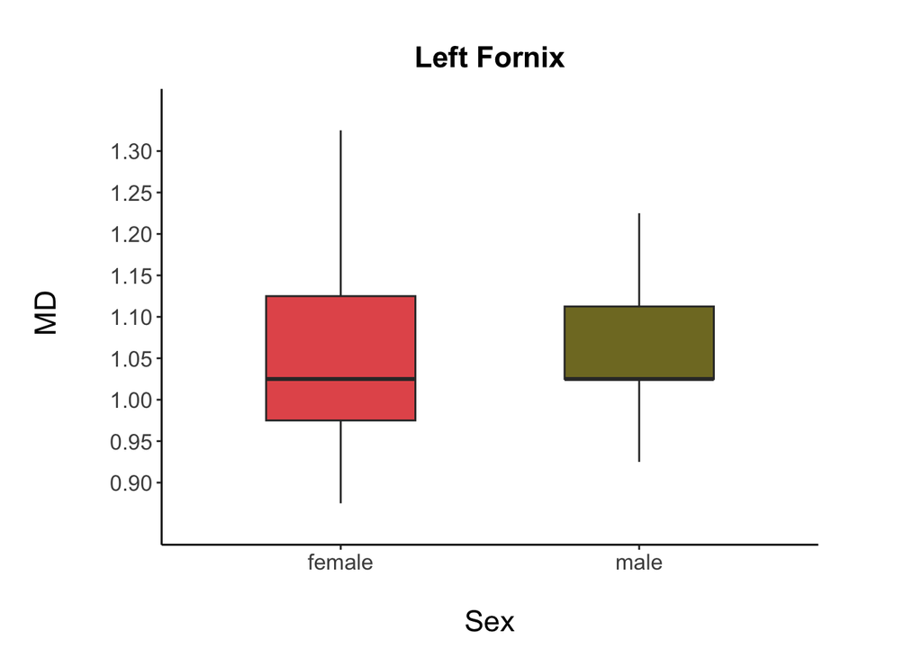

```r
  MD_L_Fornix <- MDdf %>%
    ggplot(aes(x=sex, y= md_Fornix_L, group=sex)) +
      geom_boxplot(width=0.5 ,fill= c("#E45A5A", "#80792B")) +
      scale_y_binned(n.breaks=10, nice.breaks = TRUE) +
      labs(x= "Sex", y= " MD", title ="Left Fornix" ) +
      theme(axis.title.x = element_text(vjust=- 4, size = 16),
            axis.title.y = element_text(vjust=8, size = 16),
            axis.text.x = element_text(size = 12),
            axis.text.y = element_text(size = 12),
            panel.background =element_blank(),
            axis.line = element_line(colour = "black"),
            plot.margin = margin(1, 2, 1, 1.5, "cm"),
            plot.title = element_text(hjust = 0.5, vjust = 2, size = 16, face="bold"))

print(MD_L_Fornix)
```

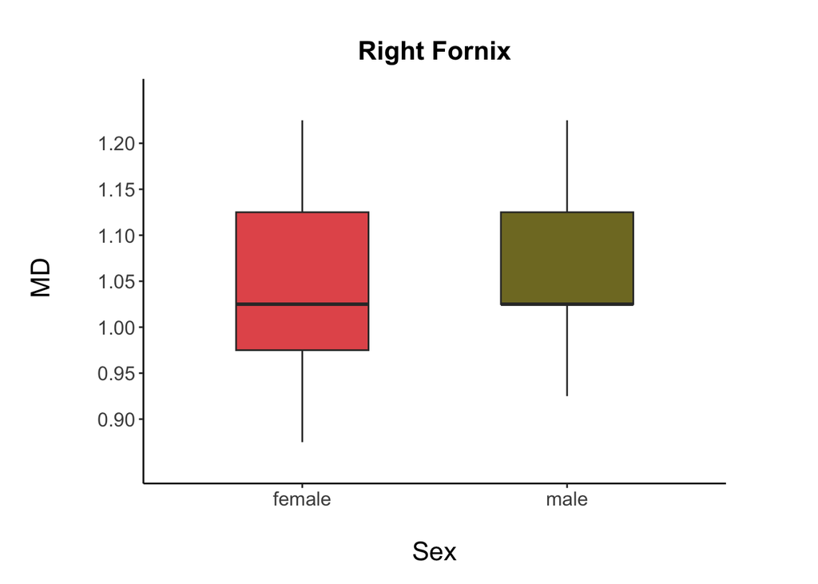

```r
  MD_R_Fornix <- MDdf %>%
    ggplot(aes(x=sex, y= md_Fornix_R, group=sex)) +
      geom_boxplot(width=0.5 ,fill= c("#E45A5A", "#80792B")) +
      scale_y_binned(n.breaks=10, nice.breaks = TRUE) +
      labs(x= "Sex", y= " MD", title ="Right Fornix" ) +
      theme(axis.title.x = element_text(vjust=- 4, size = 16),
            axis.title.y = element_text(vjust=8, size = 16),
            axis.text.x = element_text(size = 12),
            axis.text.y = element_text(size = 12),
            panel.background =element_blank(),
            axis.line = element_line(colour = "black"),
            plot.margin = margin(1, 2, 1, 1.5, "cm"),
            plot.title = element_text(hjust = 0.5, vjust = 2, size = 16, face="bold"))

print(MD_R_Fornix)
```

# AD

## Summary

## Men

**Distribution of data**

The normality of the AD values was assessed using the shapiro-wilks test of normality. AD values from males was normally distributed for **left cingulum** (p = 0.2789865), **right cingulum** (p=0.4618923), **Left fornix** (p=0.089337), and **Right Fornix** (p = 0.4858816).

**Table 1.p values from normality tests using shapiro-wilks.**

|  | Left cingulum | Right cingulum | Left Fornix | Right Fornix |
| --- | --- | --- | --- | --- |
| Males | 0.2789865 | 0.4618923 | 0.089337 | 0.4858816 |

**Descriptive stats**

```r
m_AD_cing_L_summary <- summary(m_AD$ad_Cingulum_L)
m_AD_cing_R_summary <- summary(m_AD$ad_Cingulum_R)

m_AD_fornix_R_summary <- summary(m_AD$ad_Fornix_R)
m_AD_fornix_L_summary <- summary(m_AD$ad_Fornix_L)

AD_male_summary <- rbind(m_AD_cing_L_summary, m_AD_cing_R_summary,m_AD_fornix_L_summary,m_AD_fornix_R_summary) %>% `row.names<-`(c("Left cingulum", "Right cingulum", "Left Fornix", "Right Fornix")) %>% as.data.frame()
```

|  | Min. | 1st Qu. | Median | Mean | 3rd Qu. | Max. |
| --- | --- | --- | --- | --- | --- | --- |
| Left cingulum | 1.08228 | 1.103720 | 1.121170 | 1.123348 | 1.134667 | 1.19689 |
| Right cingulum | 1.11770 | 1.147230 | 1.163960 | 1.162008 | 1.174815 | 1.22153 |
| Left Fornix | 1.31769 | 1.357028 | 1.395265 | 1.414214 | 1.468357 | 1.58189 |
| Right Fornix | 1.32592 | 1.391538 | 1.419145 | 1.434235 | 1.485623 | 1.58062 |

## Women

**Distribution of data**

The normality of the AD values was assessed using the shapiro-wilks test of normality. AD values from females was normally distributed for **left cingulum** (p = 0.6202216), **right cingulum** (p=0.5757955), **Left fornix** (p=0.3188139), and **Right Fornix** (p = 0.6214636).

**Table 1.p values from normality tests using shapiro-wilks.**

[output not shown]

**Descriptive stats**

```r
f_AD_cing_L_summary <- summary(f_AD$ad_Cingulum_L)
f_AD_cing_R_summary <- summary(f_AD$ad_Cingulum_R)

f_AD_fornix_R_summary <- summary(f_AD$ad_Fornix_R)
f_AD_fornix_L_summary <- summary(f_AD$ad_Fornix_L)

AD_female_summary <- rbind(f_AD_cing_L_summary, f_AD_cing_R_summary,f_AD_fornix_L_summary,f_AD_fornix_R_summary) %>% `row.names<-`(c("Left cingulum", "Right cingulum", "Left Fornix", "Right Fornix")) %>% as.data.frame()
```

|  | Min. | 1st Qu. | Median | Mean | 3rd Qu. | Max. |
| --- | --- | --- | --- | --- | --- | --- |
| Left cingulum | 1.07140 | 1.097590 | 1.114805 | 1.114267 | 1.128967 | 1.15865 |
| Right cingulum | 1.11186 | 1.138480 | 1.150550 | 1.152136 | 1.167825 | 1.19782 |
| Left Fornix | 1.27931 | 1.384777 | 1.424115 | 1.433264 | 1.495935 | 1.67023 |
| Right Fornix | 1.27408 | 1.384120 | 1.427820 | 1.436577 | 1.492163 | 1.61463 |

## T Test

**P values from t tests**

| Left cingulum | Right cingulum | Left Fornix | Right Fornix |
| --- | --- | --- | --- |
| 0.1557591 | 0.0966508 | 0.2395967 | 0.8937783 |

# RD

## Summary

## Men

## Women

## T Test